# Missed appointment analysis

Ravshan S.K.

December 6, 2018

## Data Exploration

### Outliers

First of all, we explore the dataset. We immediately notice that some age values are negative, and very old patients don’t exhibit variation having too few observations:

```r
table(df$age)
```

```
##
##   -1    0    1    2    3    4    5    6    7    8    9   10   11   12   13
##    1 3539 2273 1618 1513 1299 1489 1521 1427 1424 1372 1274 1195 1092 1103
##   14   15   16   17   18   19   20   21   22   23   24   25   26   27   28
## 1118 1211 1402 1509 1487 1545 1437 1452 1376 1349 1242 1332 1283 1377 1448
##   29   30   31   32   33   34   35   36   37   38   39   40   41   42   43
## 1403 1521 1439 1505 1524 1526 1378 1580 1533 1629 1536 1402 1346 1272 1344
##   44   45   46   47   48   49   50   51   52   53   54   55   56   57   58
## 1487 1453 1460 1394 1399 1652 1613 1567 1746 1651 1530 1425 1635 1603 1469
##   59   60   61   62   63   64   65   66   67   68   69   70   71   72   73
## 1624 1411 1343 1312 1374 1331 1101 1187  973 1012  832  724  695  615  725
##   74   75   76   77   78   79   80   81   82   83   84   85   86   87   88
##  602  544  571  527  541  390  511  434  392  280  311  275  260  184  126
##   89   90   91   92   93   94   95   96   97   98   99  100  102  115
##  173  109   66   86   53   33   24   17   11    6    1    4    2    5
```

Moreover, some appointments have been done to the dates before it was scheduled, probably, due to some system error.

```r
table(as.numeric(df$dayap - df$daysc)<0)
```

```
##
##  FALSE   TRUE
## 110522      5
```

We remove the obvious outliers from our data, combine all data points for households older than 80 (to balance subset size), and continue with our analysis.

```r
df <- df[ (df$age >= 0) & (df$dayap >= df$daysc),]
```

### Demographic factors

#### Age factor

Observing the no-show dynamics throughout lifetime, gives important insights to our analysis:

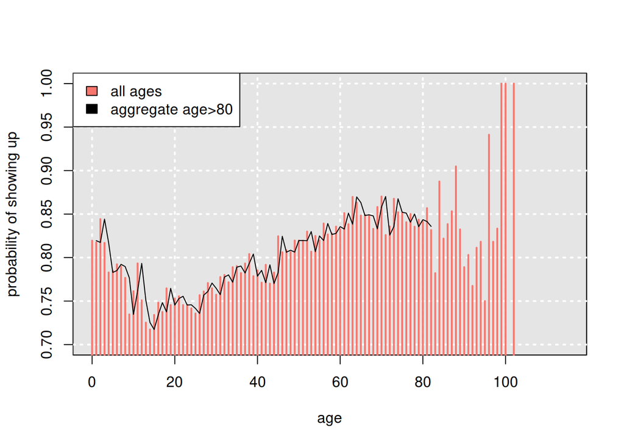

From common experience, we know that appointments for patients younger than 18, are actually done by their parents. We can see how, as kids grow older, the parents tend to miss more appointments (because new parents tend to be concerned more with infant’s health, and as kids grow, parents tend to neglect their health slightly more).

As kids grow into young adults, they start steadily taking their health seriously and miss less appointments.

Also, for patients older than 80, we don’t have many data points at particular ages, so we aggregated them into one group.

So, we use two possible age variables: a continuous one with two dummies for 18 and 80 year olds, and a discrete variable correpsonding to 11 decades of patients. #### Gender factor Another demographic factor is gender. The probability distribution shows that gender does not play a significant role in no-show rate:

```
##             show    noshow
## female 0.7968846 0.2031154
## male   0.8003619 0.1996381
```

We tried to look at adults only (age>=18), because usually mothers (female=1) go to doctors with their children, irrespective of the kid’s registered gender, but this procedure returned no significant difference either:

```
##             show    noshow
## female 0.8010114 0.1989886
## male   0.8099980 0.1900020
```

We ignore gender in further discussion.

### Geographic factor

Looking at no-show rates by neighbourhood shows relative balance, with only a few outliers, which do not round to 20%.

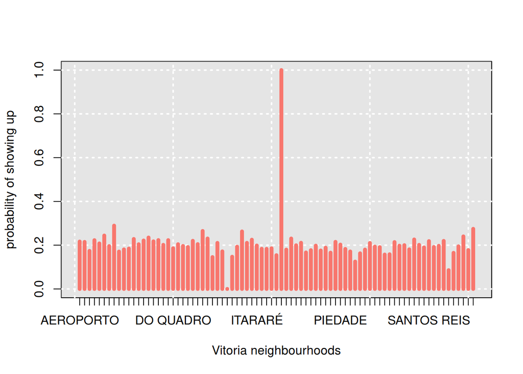

We see that most (not all) of the outliers come from neighbourhoods with little data:

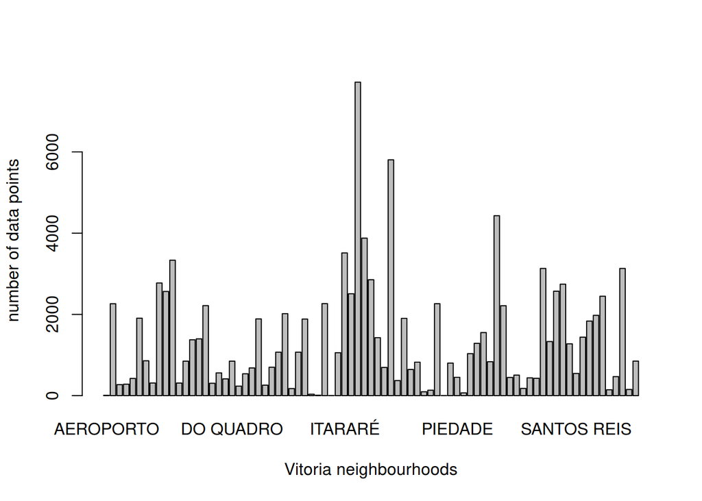

Therefore, we ignore neighbourhoods with less than 40 data points to avoid wrong statistics (e.g. in Parque Industrial there is only one registered appointment and it shows 100% show-up rate, which is incomparable with neighbourhoods with thousands of observations.) So, we ignore neigbourhoods *Aeroporto, Ilha do Boi, Ilha do Frade, Ilhas Oceanicas de Trinade, and Parque Industrial*.

Now, we still have outliers (we considered 3% to be a significant deviation from the average, 20%) in percentage of no-shows, which have sufficient observations not to ignore them. They are: *Solon Borges, Santos Dumont, Santa Clara, Santa Cecilia, Itarare, De Lourdes, Do Cabral, Do Quadro, Horto, Jardim Da Penha, Jesus de Nazareth, Mario Cypreste, and Santa Martha*.

We will add dummy variables for these 13 neighbourhoods as our geographic predictors. Other neighborhoods will be assumed to contribute no new information to the expected value.

```r
df$solbor <- ifelse(df$rayon=="SOLON BORGES",1,0)
df$sandum <- ifelse(df$rayon=="SANTOS DUMONT",1,0)
df$sancla <- ifelse(df$rayon=="SANTA CLARA",1,0)
df$sancec <- ifelse(df$rayon=="SANTA CECÍLIA",1,0)
df$itarar <- ifelse(df$rayon=="ITARARÉ",1,0)
df$lourde <- ifelse(df$rayon=="DE LOURDES",1,0)
df$cabral <- ifelse(df$rayon=="DO CABRAL",1,0)
df$quadro <- ifelse(df$rayon=="DO QUADRO",1,0)
df$horto  <- ifelse(df$rayon=="HORTO",1,0)
df$penha  <- ifelse(df$rayon=="JARDIM DA PENHA",1,0)
df$jesus  <- ifelse(df$rayon=="JESUS DE NAZARETH",1,0)
df$cypres <- ifelse(df$rayon=="MÁRIO CYPRESTE",1,0)
df$sanmar <- ifelse(df$rayon=="SANTA MARTHA",1,0)
```

### Temporal factor

Temporal data brings the crucial information about the appointment no-shows, starting from the weekday of the appointment, and ending with the wait time. Since we don’t have at least a year-long data, we cannot speak of seasonality patterns, and will have to get by with what we have.

#### Weekdays

The day of the week is the first thing that comes to mind - during the weekdays, patients might have emergencies at school or at work, and this could cause them to miss the appointment. However, the analysis shows no significant difference through week, except for Saturdays:

[figure not shown]

But further analysis shows that this happens because of the lack of enough data for Saturday:

```r
table(df$wdayap,df$noshow)
```

```
##
##         0     1
##   1 18024  4689
##   2 20488  5150
##   3 20774  5092
##   4 13909  3337
##   5 14982  4037
##   6    30     9
```

```r
table(df$wdaysc,df$noshow)
```

```
##
##         0     1
##   1 18523  4561
##   2 20877  5290
##   3 19383  4876
##   4 14373  3699
##   5 15028  3887
##   6    23     1
```

So, we ignore the weekdays and assume that they don’t affect the no-show rate.

#### Wait time

Another obvious variable is a wait time from scheduling the appointment to the appointment itself. It is plausible to assume that in longer wait times patients can get cured, book another earlier appointment, or die before the appointment.

We define the “days between” variable as the difference between “day of appointment” and “day of schedule”:

```r
df$daybw <- as.numeric(df$dayap - df$daysc)
```

The plot below shows that when appointments are scheduled in that same day (wait time = 0), the patient almost never misses it (just 4% no-show rate). There is sufficient data (34% of all observations) to support this claim.

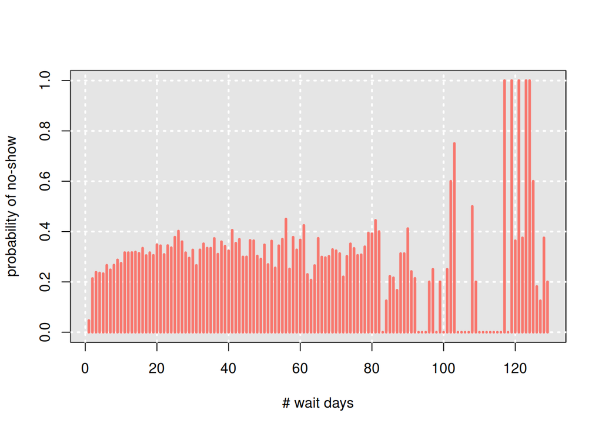

In the next days, the no-show rate is very volatile. To avoid weekly seasonality, we aggregate the data by weeks. Also, for two reasons: *(i)* since the longer wait times have small data points and *(ii)* since (assuming time discounting — a weak economic assumption) people perceive recent past clearer than distant past, we aggregated first month as 4 weeks, and aggregated the next data points by month:

```
##               show    no show
## 0 days   0.9535294 0.04647062
## 1 week   0.7585211 0.24147895
## 2 weeks  0.6953015 0.30469854
## 3 weeks  0.6775975 0.32240252
## 4 weeks  0.6633353 0.33666468
## 2 months 0.6662968 0.33370322
## 3 months 0.7034588 0.29654120
## 4 months 0.7363014 0.26369863
```

Note that *4 months* wait is an outlier due to small dataset. Otherwise, all probabilities after 1 week fall into ±3% interval. Taking this and *(ii)* into consideration, suggests an even wilder (yet still plausible) aggregation: *0 days, 1 week, and >1 week*:

```
##              show    no show
## 0 days  0.9535294 0.04647062
## 1 week  0.7585211 0.24147895
## >1 week 0.6794388 0.32056117
```

Thus, we will use three-valued categorical variables to denote wait times.

#### Hour of the day

Lifestyle of people potentially reflects their degree of responsibility — *“night owls”* tend to sleep during days and maybe miss deadlines, while *“early birds”* may take their appointments more seriously. We take a look at the data of time o’clock when the appointment was scheduled. The online appointment system opens at 6AM and closes at 10PM. We divide these 16-hour days into 4 groups of 4, and find that *“early bird effect”* actually exists, and people who scheduled appointments between 6AM and 10AM are significantly less likely to miss their appointments, while any other time slot does not change the no-show probability significantly:

```
##                show   no show
## 6AM-10AM: 0.8255142 0.1744858
## 10AM-2PM: 0.7833574 0.2166426
## 2PM-6PM:  0.7668771 0.2331229
## 6PM-10PM: 0.7773175 0.2226825
```

Thus, we use a binary dummy variable — *6AM-10AM* or *10AM-10PM* — to incorporate time.

### Medical factor

#### Appointment history

To incorporate the idiosyncracies of patients, we use the history of their previous appointments, and whether they missed them before. The table below shows the repeat patients’ allocation.

```
##
##     0     1     2     3     4     5     6     7     8     9    10    11
## 62295 24378 10484  4984  2616  1498   945   639   437   333   248   185
##    12    13    14    15    16    17    18    19    20    21    22    23
##   149   114    92    77    67    57    49    43    35    32    31    29
##    24    25    26    27    28    29    30    31    32    33    34    35
##    28    28    28    28    28    27    25    25    25    24    22    21
##    36    37    38    39    40    41    42    43    44    45    46    47
##    21    20    18    18    17    17    15    15    15    15    13    13
##    48    49    50    51    52    53    54    55    56    57    58    59
##    13    13    12    11    11    11    10     9     9     8     8     8
##    60    61    62    63    64    65    66    67    68    69    70    71
##     8     8     4     4     4     3     3     3     3     3     2     2
##    72    73    74    75    76    77    78    79    80    81    82    83
##     2     2     2     2     2     2     2     2     2     2     2     2
##    84    85    86    87
##     1     1     1     1
```

For every patient, we found the modes (most frequent observations) of previous no-show stats. For patients that appear in the dataset only once, this value will be 0 (performing sensitivity checks we learned that leaving out one-time patients entirely, returns no significant difference (<0.5%) but complicates the dataset, so we chose to set the average previous no-show rate for first-time patients at 0). We observe that such modes greatly contribute to predicting the next no-show:

```
##             show    noshow
## mode0: 0.8116890 0.1883110
## mode1: 0.6652691 0.3347309
```

#### Patient condition

Patient’s medical history can influence the no-show behavior. The tables below show differences in percentage of no-shows for patients with alcoholism, diabetes, hipertension, medical financial assitance (so-called “scholarship”), and handicaps:

```
##                     show   no show
## no scholarship 0.8019667 0.1980333
## scholarship    0.7626370 0.2373630
```

```
##                      show   no show
## no hipertension 0.7910054 0.2089946
## hipertension    0.8269804 0.1730196
```

```
##                  show   no show
## no diabetes 0.7964086 0.2035914
## diabetes    0.8199673 0.1800327
```

```
##                 show   no show
## no alcohol 0.7980889 0.2019111
## alcohol    0.7985119 0.2014881
```

```
##                 show   no show
## handicap0: 0.7976672 0.2023328
## handicap1: 0.8215686 0.1784314
## handicap2: 0.7978142 0.2021858
## handicap3: 0.7692308 0.2307692
## handicap4: 0.6666667 0.3333333
```

Strangely, alcoholism is the only condition which turned out to not have an effect on no-show probability. The probable reason is that alcoholism is not immediately lethal, and people tend to treat is less seriously than any other *“more serious”* illness like diabetes. So, we include all of the above conditions, except alcoholism, in our classification.

#### SMS

```
##              show    no show
## no sms 0.56558482 0.11337212
## sms    0.23251690 0.08852616
```

#### Overall no-show stata

Finally, we decided to include the general historical average of noshows till the moment by all patients. However, this complicated the random sampling, and, most importantly, didn’t affect the final result much (because it had little variation over time). So, we did not include this variable.

## Classifier

We used *logit* (logistic regression) and *decision trees* to classify the data.

### Logit

```r
logit <- glm(formula =
               noshow ~ age + age18 + age80 +
               burs + diabet + handcap + alcohol +
               solbor + sandum + itarar + lourde + cabral + quadro + penha + jesus + sanmar +
               sms + morning + waittime + mode_previous,
             family = binomial(link="logit"),
             data = dftrain
             )
summary(logit)
```

```
##
## Call:
## glm(formula = noshow ~ age + age18 + age80 + burs + diabet +
##     handcap + alcohol + solbor + sandum + itarar + lourde + cabral +
##     quadro + penha + jesus + sanmar + sms + morning + waittime +
##     mode_previous, family = binomial(link = "logit"), data = dftrain)
##
## Deviance Residuals:
##     Min       1Q   Median       3Q      Max
## -1.5490  -0.7291  -0.4477  -0.3346   2.6454
##
## Coefficients:
##                 Estimate Std. Error z value             Pr(>|z|)
## (Intercept)   -2.3027581  0.0267987 -85.928 < 0.0000000000000002 ***
## age           -0.0125877  0.0006706 -18.772 < 0.0000000000000002 ***
## age18          0.2659647  0.0312217   8.519 < 0.0000000000000002 ***
## age80          0.3157662  0.0606324   5.208  0.00000019101044335 ***
## burs           0.1972190  0.0286774   6.877  0.00000000000610610 ***
## diabet         0.1544029  0.0372166   4.149  0.00003342670672459 ***
## handcap        0.0915749  0.0563530   1.625             0.104158
## alcohol        0.3330153  0.0522980   6.368  0.00000000019194428 ***
## solbor        -0.4963353  0.1532160  -3.239             0.001198 **
## sandum         0.2988702  0.0764425   3.910  0.00009239634926811 ***
## itarar         0.2022540  0.0464296   4.356  0.00001323766938002 ***
## lourde        -0.5588738  0.1891486  -2.955             0.003130 **
## cabral        -0.3399142  0.1339569  -2.537             0.011165 *
## quadro        -0.2988064  0.1078614  -2.770             0.005601 **
## penha         -0.3093562  0.0516199  -5.993  0.00000000206043028 ***
## jesus          0.1934662  0.0537897   3.597             0.000322 ***
## sanmar        -0.1660085  0.0588319  -2.822             0.004776 **
## sms           -0.1569562  0.0200545  -7.826  0.00000000000000502 ***
## morning       -0.1422520  0.0177617  -8.009  0.00000000000000116 ***
## waittime       0.9883130  0.0130948  75.474 < 0.0000000000000002 ***
## mode_previous  0.7399796  0.0268507  27.559 < 0.0000000000000002 ***
## ---
## Signif. codes:  0 '***' 0.001 '**' 0.01 '*' 0.05 '.' 0.1 ' ' 1
##
## (Dispersion parameter for binomial family taken to be 1)
##
##     Null deviance: 88976  on 88416  degrees of freedom
## Residual deviance: 79780  on 88396  degrees of freedom
## AIC: 79822
##
## Number of Fisher Scoring iterations: 5
```

We found that the wait time, previous no-show history, and geographical location were the most important predictors. Also, alcohol turned out to be statistically significant, while hipertension had to be removed from the final model. Strangely, eligibility to financial assistance increased the likelihood of no-show (but this was discussed in the previous section).

To check the accuracy of the model, we predict the no-show for the test data and use measures called *accuracy* and *AUR*:

```r
predicted_noshow <- ifelse(predict(logit, dftest,type = "response")>=0.5,1,0)
actual_noshow <- dftest$noshow
mytab <- table(abs(predicted_noshow - actual_noshow))

accuracy <- mytab[1]/(mytab[1] + mytab[2])
accuracy
```

```
##         0
## 0.8000362
```

```r
roc(actual_noshow, predicted_noshow)
```

```
##
## Call:
## roc.default(response = actual_noshow, predictor = predicted_noshow)
##
## Data: predicted_noshow in 17650 controls (actual_noshow 0) < 4454 cases (actual_noshow 1).
## Area under the curve: 0.5231
```

So, we decide to take a look at decision trees:

### Decision trees

The decision tree returns 79% accuracy and 50.6% *AUR* on average. Different tree specifications give different resulting trees, but the average accuracy doesn’t change. Here is just one of the trees. Notice that we used age as decades here, and not as a continuous variable:

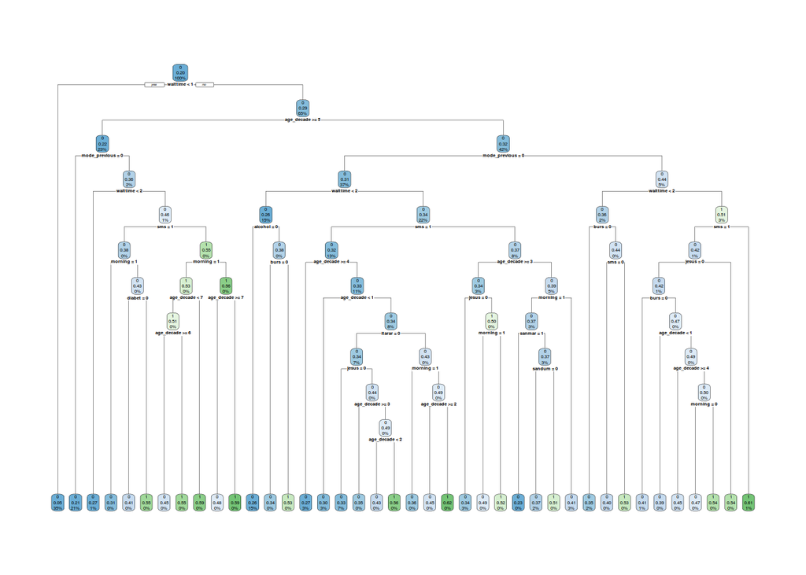

```r
dtree <- rpart(formula=noshow ~ age_decade +
                 burs + diabet + handcap + alcohol + hiper +
                 solbor + sandum + itarar + lourde + cabral + quadro + penha + jesus + sanmar +
                 sms + morning + waittime + mode_previous,
               data = df,
               method = "class",
               control = rpart.control(xval = 5, cp=0.0000001, minsplit=100)
               )
rpart.plot(dtree)
```

## Conclusion

We have analyzed the data and tried to do a classification analysis. The results are not perfectly accurate, but they are not worse than a naive “noshow=0” prediction.

As an economist, I believe that having a higher accuracy would be impossible without additional data, like weather that day (was it rainy or not), the traffic situation, the diagnosis, the local news etc.

And here, we conclude.